# HW 4&5

Group15

02 07 2021

# Introduction

This assignment mainly focuses on a variety of forecasting methods which is used for the term project. At first, analysing every product for seasonality is required. However, daily decomposition can be used because of insufficient information and data. This is because Trendyol does not like to make these data which is before May 2020 public, possibly due to privacy concerns. Therefore, we cannot make monthly and weekly decomposition. The most suitable ARIMA is needed to build according to decomposition for each product. Secondly, for each product, a potential regressor analysis will be performed in connection to the number of goods sold. In order to get better forecast values, ARIMAX models will be built using given regressors.

```r
library(caTools)
library(xts)
library(zoo)
library(forecast)
library(urca)
library(ggplot2)
library(dplyr)

rawdata <- read.csv("C:/Users/MERVE/Desktop/spring21-Umutdilsiz/HW4&5/ProjectRawData.csv.", header=TRUE)
alldata<-rbind(rawdata,data)
alldata<-as.data.table(alldata)
```

# Trendyol Tayt

## Decomposition

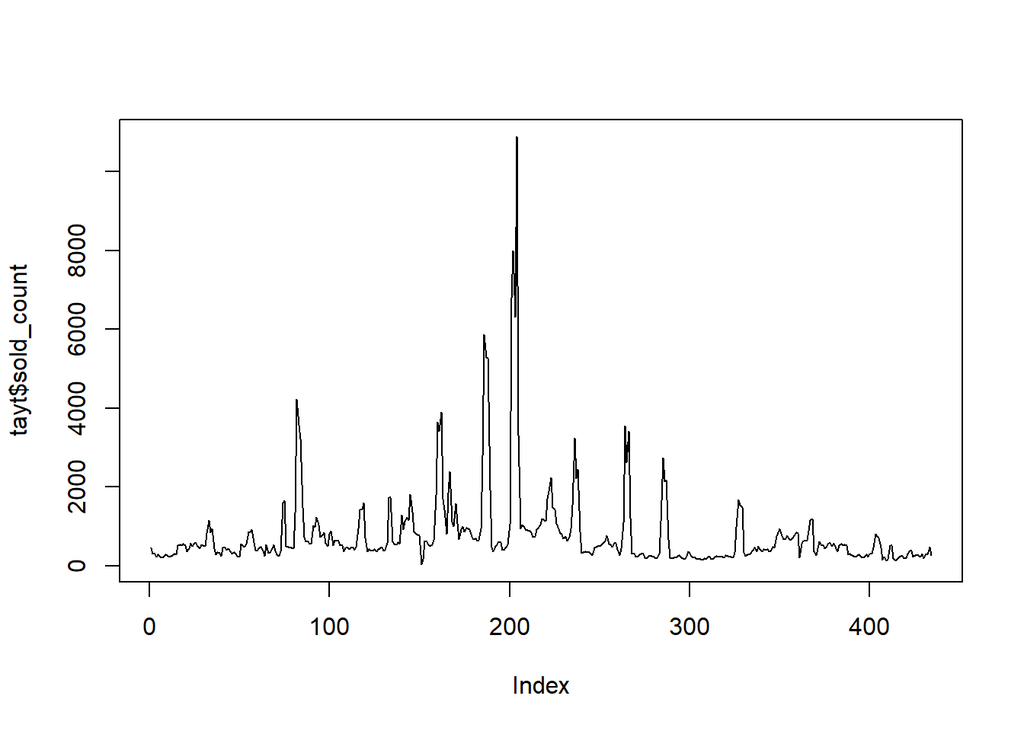

```r
tayt<-subset(alldata, alldata$product_content_id==31515569)
tayt_daily_tr<-tayt[tayt$event_date<"2021-05-21"]
tayt_daily_te<-tayt[tayt$event_date>="2021-05-21"]
plot(tayt$sold_count, type='l')
```

The chart above shows the sales volumes of Trendyolmilla Tayt. The tayt have been sold all year and there are some peaks on certain days.

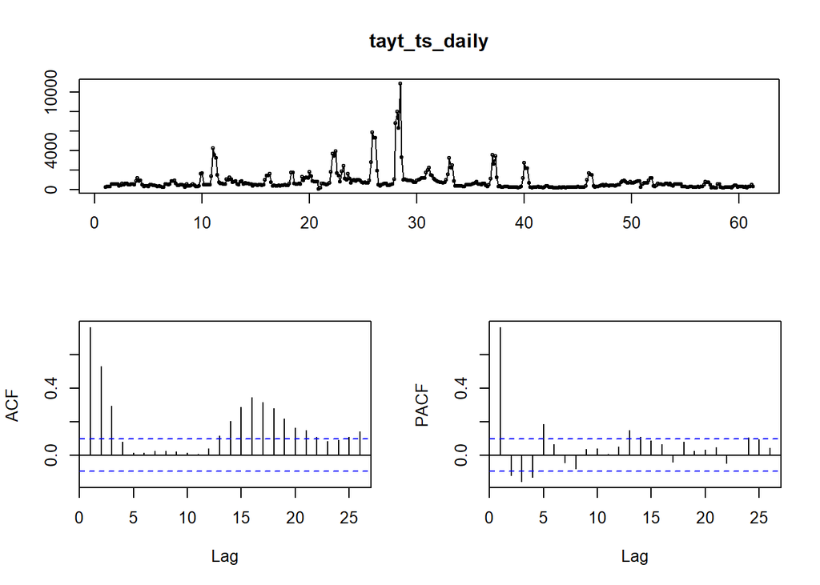

```r
tayt_ts_daily<-ts(tayt_daily_tr$sold_count, freq=7)
tsdisplay(tayt_ts_daily)
```

### Additive and Multiplicative

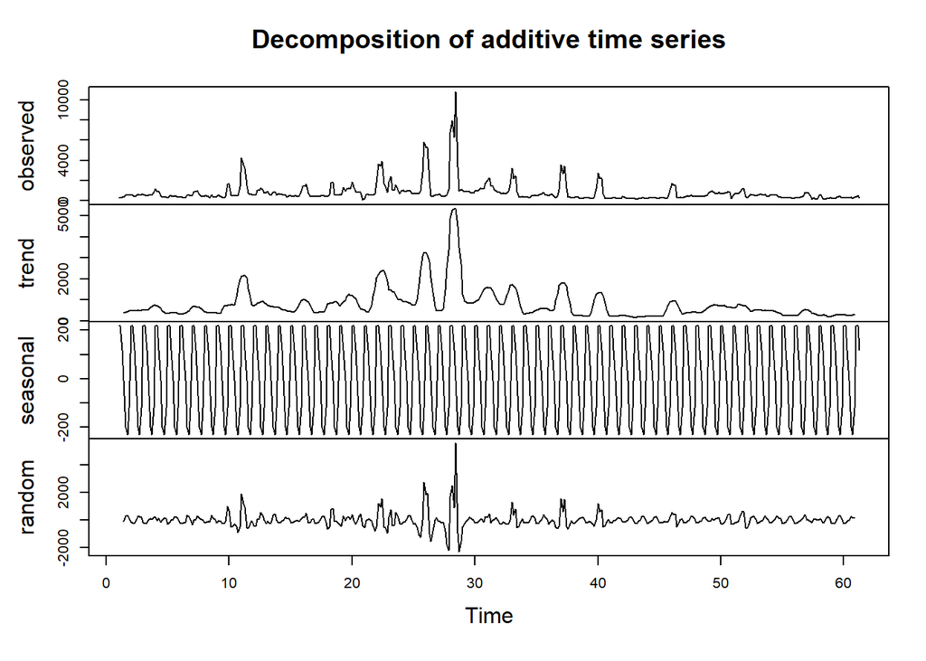

```r
tayt_daily_additive<-decompose(tayt_ts_daily, type ="additive")
tayt_daily_multiplicative<-decompose(tayt_ts_daily, type ="multiplicative")
plot(tayt_daily_additive)
```

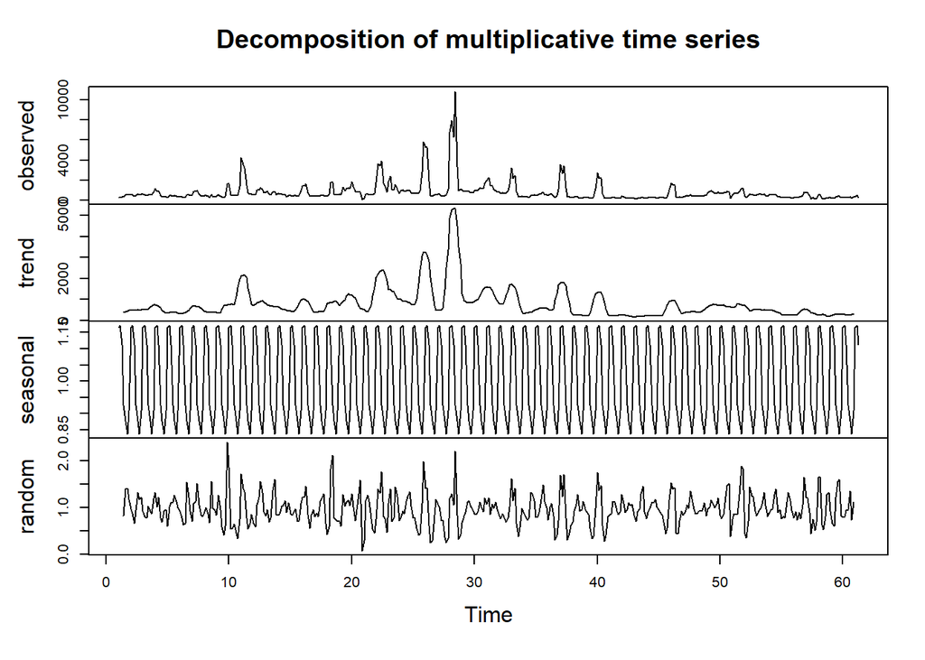

```r
plot(tayt_daily_multiplicative)
```

The graphs above show the trend, seasonal and random components of the multiplicative and additive decomposition. Since there is 0 mean assumption in the continuation of the study, we will continue on the ‘additive’ model.

```r
test1=ur.kpss(tayt_daily_additive$random, use.lag="7")
summary(test1)
```

```
##
## #######################
## # KPSS Unit Root Test #
## #######################
##
## Test is of type: mu with 7 lags.
##
## Value of test-statistic is: 0.0096
##
## Critical value for a significance level of:
##                 10pct  5pct 2.5pct  1pct
## critical values 0.347 0.463  0.574 0.739
```

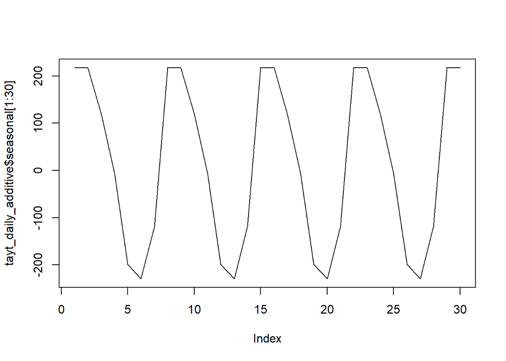

```r
plot(tayt_daily_additive$seasonal[1:30], type='l')
```

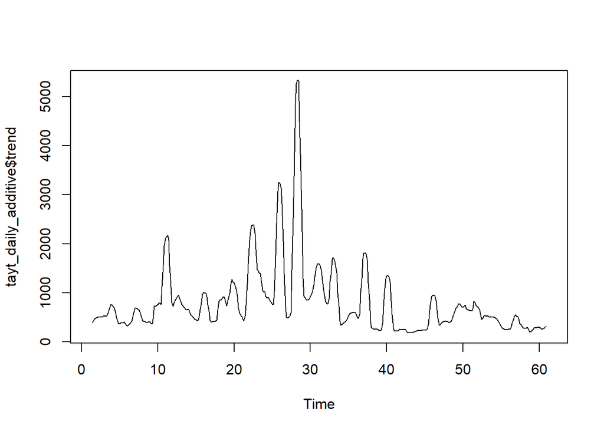

```r
plot(tayt_daily_additive$trend, type='l')
```

## ARIMA Model

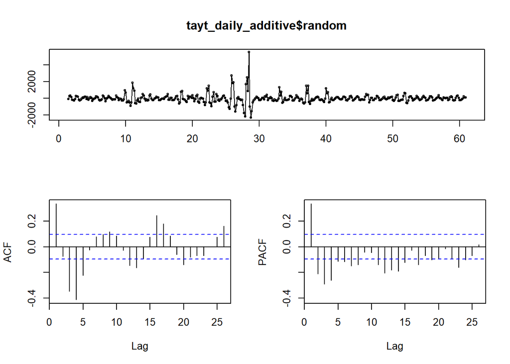

```r
tsdisplay(tayt_daily_additive$random, na.action = na.omit)
```

According to ACF plot, there is significant negative correlation at lag 4. Hence, moving average parameter should be 4. Also, it can be seen from PACF plot that correlation significantly decreased after lag 1 which means that AR parameter should be 1.Beside of this,according to the ACF graph, the delay went below the treshold after 1. So the moving average parameter should be 1. Also from the PACF graph, even if the latency is negative, it is outside the threshold up to 4, meaning that the AR parameter should be 4.

```r
tayt_model<-arima(tayt_daily_additive$random, order = c(1,0,4))
AIC(tayt_model)
```

```
## [1] 6276.312
```

```r
tayt_model2<-arima(tayt_daily_additive$random, order = c(1,0,3))
AIC(tayt_model2)
```

```
## [1] 6291.517
```

```r
tayt_model3<-arima(tayt_daily_additive$random, order = c(1,0,2))
AIC(tayt_model3)
```

```
## [1] 6402.349
```

```r
tayt_model4<-arima(tayt_daily_additive$random, order = c(4,0,1))
AIC(tayt_model4)
```

```
## [1] 6239.909
```

```r
tayt_model5<-arima(tayt_daily_additive$random, order = c(4,0,2))
AIC(tayt_model5)
```

```
## [1] 6241.442
```

Fitting the model

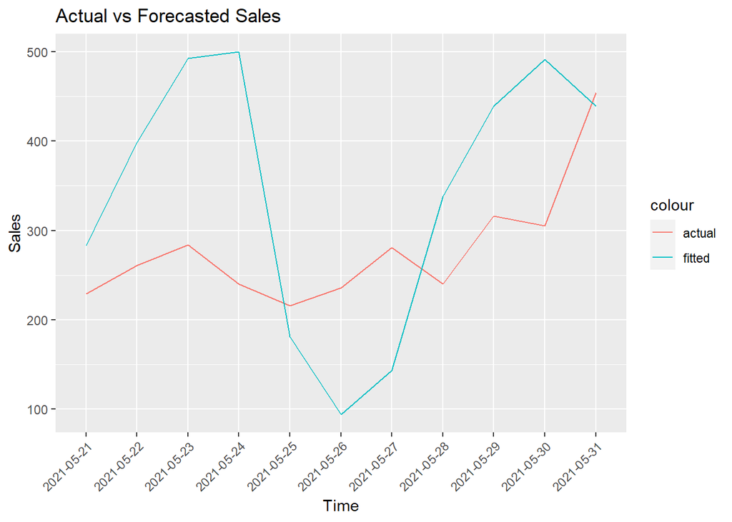

```r
model_forecast_error <- predict(tayt_model4, n.ahead = 11)$pred
last_trend_value <-tail(tayt_daily_additive$trend[!is.na(tayt_daily_additive$trend)],1)
seasonality=tayt_daily_additive$seasonal[295:305]
tayt_arima_forecast=model_forecast_error+seasonality+last_trend_value

tayt_daily_te$forecast<-paste(tayt_arima_forecast)
tayt_daily_te$forecast<-as.numeric(tayt_daily_te$forecast)

ggplot(tayt_daily_te ,aes(x=event_date)) +
        geom_line(aes(y=sold_count,color='actual',group = 1)) +
        geom_line(aes(y=forecast,color='fitted',group = 1)) + labs(title = "Actual vs Forecasted Sales",
       x = "Time",
       y = "Sales"

       ) +
   theme(axis.text.x = element_text(angle = 45, hjust=1))
```

Plot above shows for 11 days actual and predicted values with ARIMA model that we built on decomposed random part. Model that we built with ARIMA (4,0,1) parameters shows peaks and downs on sales. It does not clearly explain actual sales data.

```r
error_test(tayt_daily_te$sold_count,tayt_daily_te$forecast)
```

```
##    n     mean       sd       bias      mape      mad     wmape        MPE
## 1 11 278.3636 66.61722 -0.2412461 0.4796037 127.0197 0.4563087 -0.2460062
```

## Regressor

```r
tayt_lm1<-lm(sold_count~visit_count, data=tayt_daily_tr)
summary(tayt_lm1)
```

```
##
## Call:
## lm(formula = sold_count ~ visit_count, data = tayt_daily_tr)
##
## Residuals:
##     Min      1Q  Median      3Q     Max
##  -734.9  -482.6  -303.6    36.0 10109.1
##
## Coefficients:
##              Estimate Std. Error t value Pr(>|t|)
## (Intercept) 7.699e+02  5.932e+01  12.979   <2e-16 ***
## visit_count 2.765e-03  2.816e-03   0.982    0.327
## ---
## Signif. codes:  0 '***' 0.001 '**' 0.01 '*' 0.05 '.' 0.1 ' ' 1
##
## Residual standard error: 1044 on 421 degrees of freedom
## Multiple R-squared:  0.002284,   Adjusted R-squared:  -8.555e-05
## F-statistic: 0.9639 on 1 and 421 DF,  p-value: 0.3268
```

```r
tayt_lm2<-lm(sold_count~category_sold+price, data=tayt_daily_tr)
summary(tayt_lm2)
```

```
##
## Call:
## lm(formula = sold_count ~ category_sold + price, data = tayt_daily_tr)
##
## Residuals:
##     Min      1Q  Median      3Q     Max
## -2413.8  -314.9   -24.7   402.9  5553.8
##
## Coefficients:
##                 Estimate Std. Error t value Pr(>|t|)
## (Intercept)   3488.22865  266.79934   13.07   <2e-16 ***
## category_sold    0.30473    0.01475   20.66   <2e-16 ***
## price          -66.97186    5.33727  -12.55   <2e-16 ***
## ---
## Signif. codes:  0 '***' 0.001 '**' 0.01 '*' 0.05 '.' 0.1 ' ' 1
##
## Residual standard error: 704.7 on 420 degrees of freedom
## Multiple R-squared:  0.5467, Adjusted R-squared:  0.5445
## F-statistic: 253.3 on 2 and 420 DF,  p-value: < 2.2e-16
```

```r
tayt_lm3<-lm(sold_count~price+favored_count+category_sold, data=tayt_daily_tr)
summary(tayt_lm3)
```

```
##
## Call:
## lm(formula = sold_count ~ price + favored_count + category_sold,
##     data = tayt_daily_tr)
##
## Residuals:
##     Min      1Q  Median      3Q     Max
## -2440.2  -283.1   -64.2   395.0  5793.0
##
## Coefficients:
##                 Estimate Std. Error t value Pr(>|t|)
## (Intercept)   3651.08995  267.00046  13.674  < 2e-16 ***
## price          -71.58649    5.41848 -13.212  < 2e-16 ***
## favored_count    0.08190    0.02284   3.586 0.000375 ***
## category_sold    0.29251    0.01494  19.576  < 2e-16 ***
## ---
## Signif. codes:  0 '***' 0.001 '**' 0.01 '*' 0.05 '.' 0.1 ' ' 1
##
## Residual standard error: 695 on 419 degrees of freedom
## Multiple R-squared:  0.5602, Adjusted R-squared:  0.557
## F-statistic: 177.9 on 3 and 419 DF,  p-value: < 2.2e-16
```

```r
tayt_lm4<-lm(sold_count~favored_count+basket_count+visit_count, data=tayt_daily_tr)
summary(tayt_lm4)
```

```
##
## Call:
## lm(formula = sold_count ~ favored_count + basket_count + visit_count,
##     data = tayt_daily_tr)
##
## Residuals:
##     Min      1Q  Median      3Q     Max
## -3934.3  -120.8    17.7   148.9  5839.3
##
## Coefficients:
##                 Estimate Std. Error t value Pr(>|t|)
## (Intercept)   -70.882670  38.648043  -1.834   0.0674 .
## favored_count  -0.020616   0.022761  -0.906   0.3656
## basket_count    0.263311   0.007647  34.432  < 2e-16 ***
## visit_count    -0.011287   0.001932  -5.842 1.04e-08 ***
## ---
## Signif. codes:  0 '***' 0.001 '**' 0.01 '*' 0.05 '.' 0.1 ' ' 1
##
## Residual standard error: 524.3 on 419 degrees of freedom
## Multiple R-squared:  0.7497, Adjusted R-squared:  0.7479
## F-statistic: 418.3 on 3 and 419 DF,  p-value: < 2.2e-16
```

```r
tayt_daily_te$forecastlm1<-predict(tayt_lm1,tayt_daily_te)
tayt_daily_te$forecastlm2<-predict(tayt_lm2,tayt_daily_te)
tayt_daily_te$forecastlm3<-predict(tayt_lm3,tayt_daily_te)
tayt_daily_te$forecastlm4<-predict(tayt_lm4,tayt_daily_te)

error_test(tayt_daily_te$sold_count,tayt_daily_te$forecastlm1)
```

```
##    n     mean       sd      bias     mape     mad    wmape       MPE
## 1 11 278.3636 66.61722 -1.887987 2.000118 525.547 1.887987 -2.000118
```

```r
error_test(tayt_daily_te$sold_count,tayt_daily_te$forecastlm2)
```

```
##    n     mean       sd        bias    mape      mad    wmape       MPE
## 1 11 278.3636 66.61722 -0.06595023 2.68911 779.0405 2.798643 0.3940803
```

```r
error_test(tayt_daily_te$sold_count,tayt_daily_te$forecastlm3)
```

```
##    n     mean       sd      bias     mape      mad    wmape       MPE
## 1 11 278.3636 66.61722 0.1615009 2.847792 814.1603 2.924808 0.6358735
```

```r
error_test(tayt_daily_te$sold_count,tayt_daily_te$forecastlm4)
```

```
##    n     mean       sd      bias      mape      mad     wmape       MPE
## 1 11 278.3636 66.61722 0.5543523 0.5884612 154.3115 0.5543523 0.5884612
```

4 different multiple linear regression models were created.Model 4 explains sales behavior better than others in terms of adjusted R squared and WMAPE. Therefore, the regressions of the 4th model with the number of preferences, the number of baskets and the number of visits will be selected.

## ARIMAX Model

```r
tayt_xreg1<-cbind(tayt_daily_tr$favored_count,
                  tayt_daily_tr$basket_count,
                  tayt_daily_tr$visit_count,
                  tayt_daily_tr$is.discount_days)
tayt_xreg2<-cbind(tayt_daily_te$favored_count,
                  tayt_daily_te$basket_count,
                  tayt_daily_te$visit_count,
                  tayt_daily_te$is.discount_days)
tayt_arimax<-Arima(tayt_ts_daily,xreg=as.matrix(tayt_xreg1),order=c(4,0,1))
tayt_daily_te$forecastarimax<-forecast(tayt_arimax,xreg=as.matrix(tayt_xreg2))$mean
error_test(tayt_daily_te$sold_count,tayt_daily_te$forecastarimax)
```

```
##    n     mean       sd      bias      mape      mad     wmape       MPE
## 1 11 278.3636 66.61722 0.3147246 0.3514968 93.26162 0.3350352 0.3390436
```

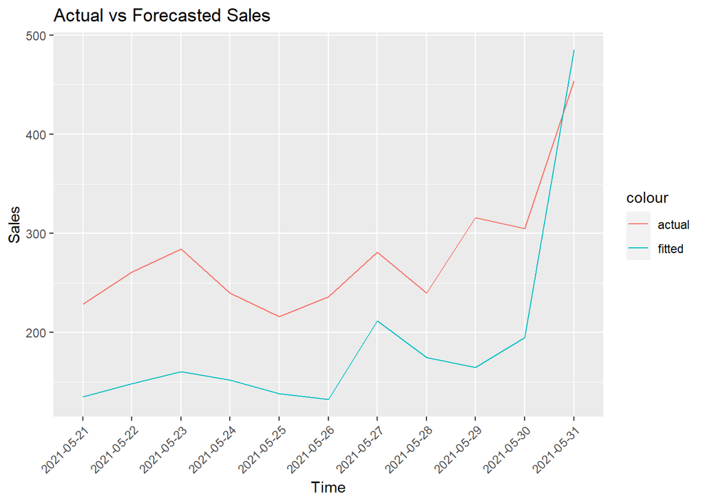

```r
ggplot(tayt_daily_te ,aes(x=event_date)) +
        geom_line(aes(y=sold_count,color='actual',group=1)) +
        geom_line(aes(y=forecastarimax,color='fitted',group=1)) + labs(title = "Actual vs Forecasted Sales",
       x = "Time",
       y = "Sales"
       )+
   theme(axis.text.x = element_text(angle = 45, hjust=1))
```

There is a difference in estimated values between the ARIMA and ARIMAX models. As can be seen from the graph above, regressors are the enhanced model.

# Trendyol Bikini 1

## Decomposition

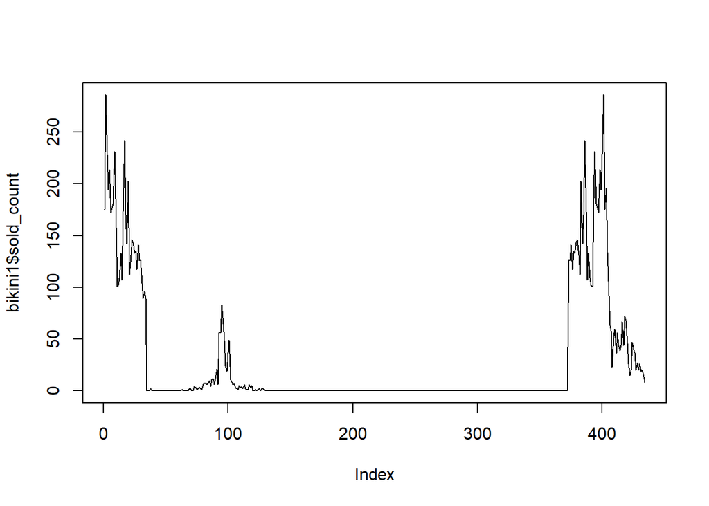

```r
bikini1<-subset(alldata, alldata$product_content_id==73318567)
bikini1_daily_tr<-bikini1[bikini1$event_date<"2021-05-21"]
bikini1_daily_te<-bikini1[bikini1$event_date>="2021-05-21"]
plot(bikini1$sold_count, type = 'l')
```

Plot above shows the sold count for bikini1. Sale volumes increased at summer and also there were sales at March.

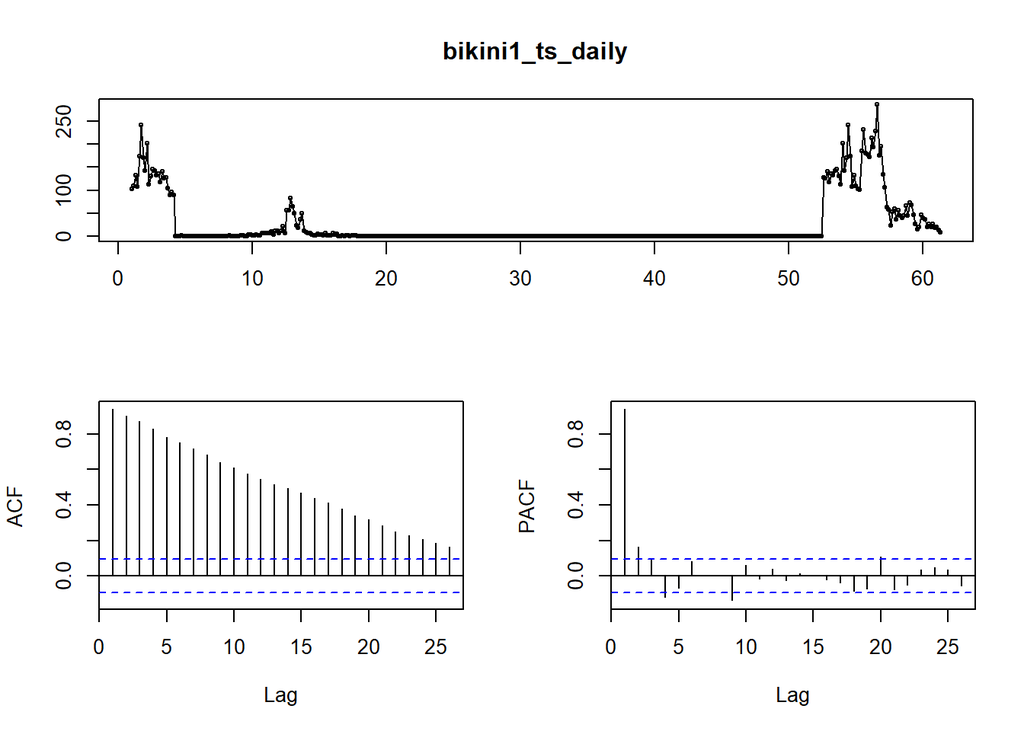

```r
bikini1_ts_daily<-ts(bikini1_daily_tr$sold_count, freq=7)
tsdisplay(bikini1_ts_daily)
```

Autocorrelation values are decreasing and PACF shows significant correlation at lag1.

### Additive and Multiplicative

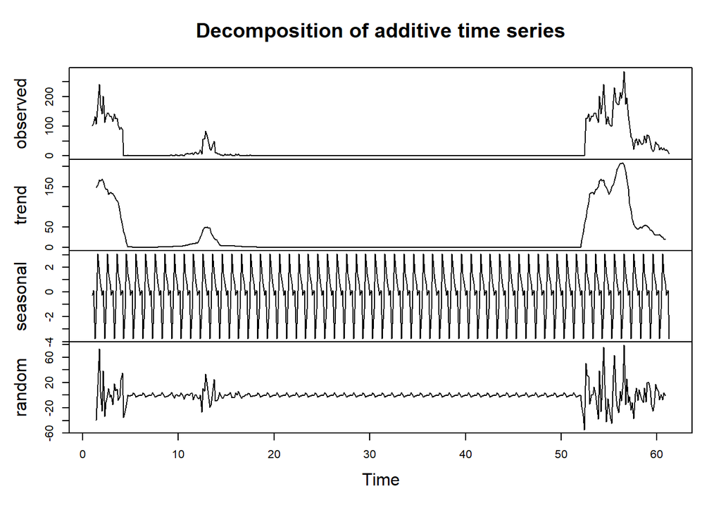

```r
bikini1_daily_additive<-decompose(bikini1_ts_daily, type ="additive")
bikini1_daily_multiplicative<-decompose(bikini1_ts_daily, type ="multiplicative")
plot(bikini1_daily_additive)
```

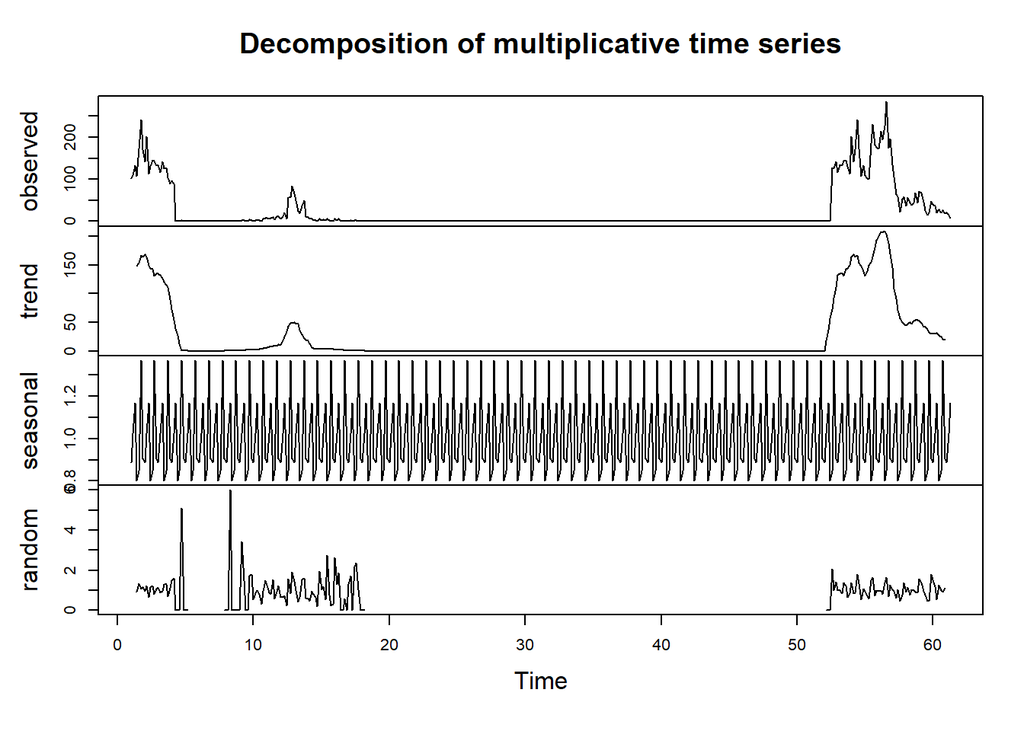

```r
plot(bikini1_daily_multiplicative)
```

The graphs above show the trend, seasonal and random components of the multiplicative and additive decomposition. Since there is 0 mean assumption in the continuation of the study, we will continue on the ‘additive’ model.

```r
test1=ur.kpss(bikini1_daily_additive$random, use.lag="7")
summary(test1)
```

```
##
## #######################
## # KPSS Unit Root Test #
## #######################
##
## Test is of type: mu with 7 lags.
##
## Value of test-statistic is: 0.0184
##
## Critical value for a significance level of:
##                 10pct  5pct 2.5pct  1pct
## critical values 0.347 0.463  0.574 0.739
```

```r
test2=ur.kpss(bikini1_daily_multiplicative$random, use.lag="7")
summary(test2)
```

```
##
## #######################
## # KPSS Unit Root Test #
## #######################
##
## Test is of type: mu with 7 lags.
##
## Value of test-statistic is: 0.0531
##
## Critical value for a significance level of:
##                 10pct  5pct 2.5pct  1pct
## critical values 0.347 0.463  0.574 0.739
```

We can see that the additive model is better by applying the kpss test.

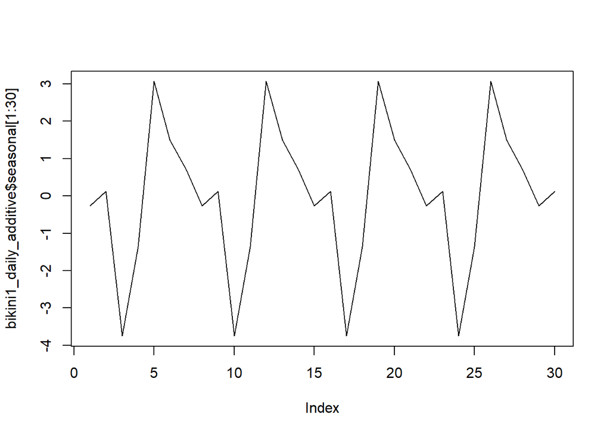

```r
plot(bikini1_daily_additive$seasonal[1:30], type='l')
```

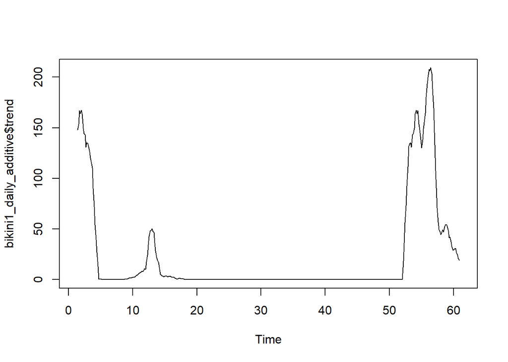

```r
plot(bikini1_daily_additive$trend, type='l')
```

By controlling the seasonal component, we can clearly see the seasonality at the daily level. The charts above show a closer look at the trend and seasonal components of additive divergence.

## ARIMA Model

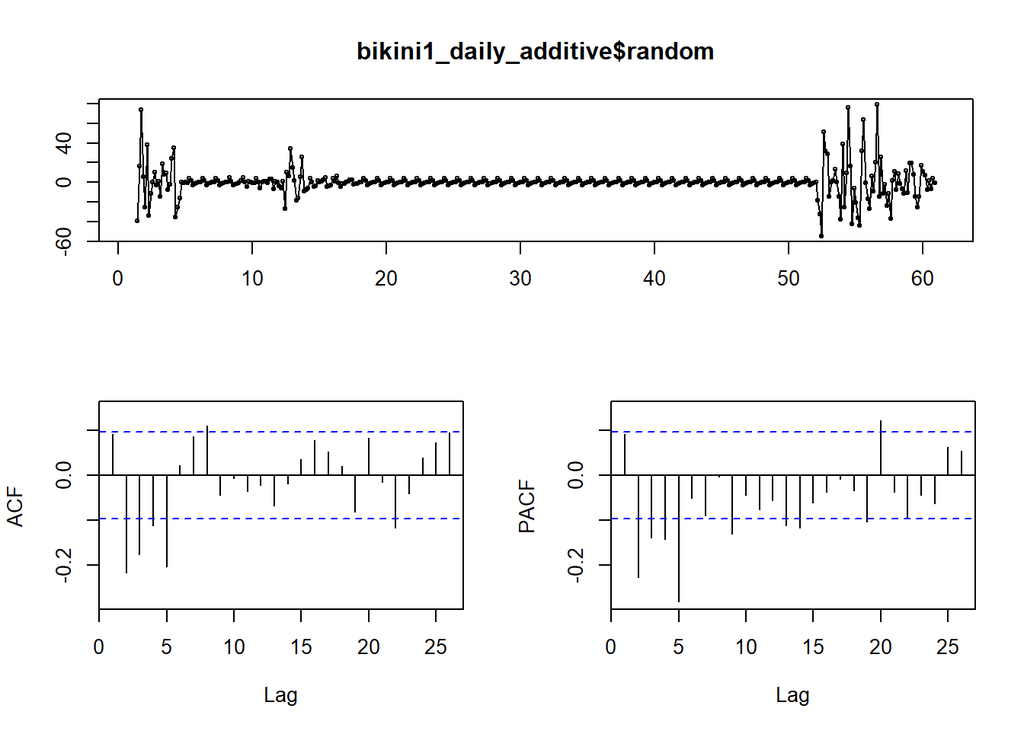

```r
tsdisplay(bikini1_daily_additive$random, na.action = na.omit)
```

As can be seen from the graphs there is significant negative autocorrelation in lag 5 at ACF and partial autocorrelation decreased significantly after lag 5 in PACF therefore parameters would be selected as (5,0,5)

```r
bikini1_model<-arima(bikini1_daily_additive$random, order = c(5,0,5))
AIC(bikini1_model)
```

```
## [1] 3179.937
```

```r
bikini1_model2<-arima(bikini1_daily_additive$random, order = c(5,0,4))
AIC(bikini1_model2)
```

```
## [1] 3181.418
```

Model 1 is better in terms of AIC values, therefore it is chosen to construct the ARIMA model.

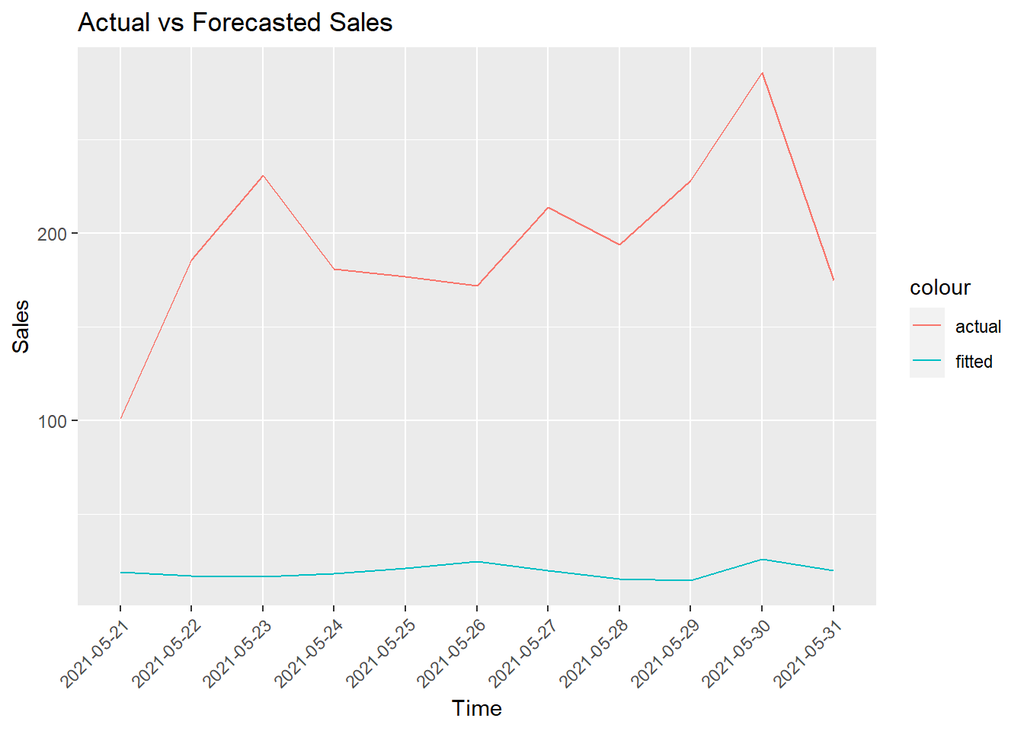

```r
model_forecast_error <- predict(bikini1_model, n.ahead = 11)$pred
last_trend_value <-tail(bikini1_daily_additive$trend[!is.na(bikini1_daily_additive$trend)],1)
seasonality=bikini1_daily_additive$seasonal[295:305]
bikini1_arima_forecast=model_forecast_error+seasonality+last_trend_value
bikini1_daily_te$forecast<-paste(bikini1_arima_forecast)
bikini1_daily_te$forecast<-as.numeric(bikini1_daily_te$forecast)
ggplot(bikini1_daily_te ,aes(x=event_date)) +
        geom_line(aes(y=sold_count,color='actual',group=1)) +
        geom_line(aes(y=forecast,color='fitted',group=1)) + labs(title = "Actual vs Forecasted Sales",
       x = "Time",
       y = "Sales"
       )+
   theme(axis.text.x = element_text(angle = 45, hjust=1))
```

From above plot, it can be seen that we are lowerpredicting, it is mainly due to the constant trend assumption, with the addition of regressors this bias may be decreased.

```r
error_test(bikini1_daily_te$sold_count,bikini1_daily_te$forecast)
```

```
##    n mean       sd      bias      mape      mad     wmape       MPE
## 1 11  195 46.25365 0.9020902 0.8960374 175.9076 0.9020902 0.8960374
```

## Regressor Search

To decide on which regressors to use, 3 different linear models are constructed and compared in terms of their error rates.

```r
bikini1_lm1<-lm(sold_count~price, data=bikini1_daily_tr)
summary(bikini1_lm1)
```

```
##
## Call:
## lm(formula = sold_count ~ price, data = bikini1_daily_tr)
##
## Residuals:
##    Min     1Q Median     3Q    Max
## -69.86 -64.86 -24.36  59.14 214.69
##
## Coefficients:
##             Estimate Std. Error t value Pr(>|t|)
## (Intercept) -118.627    832.127  -0.143    0.887
## price          3.159     13.845   0.228    0.820
##
## Residual standard error: 71.04 on 140 degrees of freedom
##   (281 observations deleted due to missingness)
## Multiple R-squared:  0.0003717,  Adjusted R-squared:  -0.006769
## F-statistic: 0.05205 on 1 and 140 DF,  p-value: 0.8199
```

```r
bikini1_lm2<-lm(sold_count~category_sold+price, data=bikini1_daily_tr)
summary(bikini1_lm2)
```

```
##
## Call:
## lm(formula = sold_count ~ category_sold + price, data = bikini1_daily_tr)
##
## Residuals:
##     Min      1Q  Median      3Q     Max
## -136.21  -37.73  -25.14   43.14  169.28
##
## Coefficients:
##                 Estimate Std. Error t value Pr(>|t|)
## (Intercept)    1.199e+03  7.741e+02   1.548    0.124
## category_sold  1.591e-02  2.629e-03   6.053 1.25e-08 ***
## price         -1.952e+01  1.292e+01  -1.512    0.133
## ---
## Signif. codes:  0 '***' 0.001 '**' 0.01 '*' 0.05 '.' 0.1 ' ' 1
##
## Residual standard error: 63.42 on 139 degrees of freedom
##   (281 observations deleted due to missingness)
## Multiple R-squared:  0.2089, Adjusted R-squared:  0.1975
## F-statistic: 18.35 on 2 and 139 DF,  p-value: 8.464e-08
```

```r
bikini1_lm3<-lm(sold_count~favored_count+basket_count, data=bikini1_daily_tr)
summary(bikini1_lm3)
```

```
##
## Call:
## lm(formula = sold_count ~ favored_count + basket_count, data = bikini1_daily_tr)
##
## Residuals:
##    Min     1Q Median     3Q    Max
## -69.94  -0.20  -0.20  -0.20  32.59
##
## Coefficients:
##                Estimate Std. Error t value Pr(>|t|)
## (Intercept)    0.200138   0.456702   0.438    0.661
## favored_count -0.016241   0.001235 -13.150   <2e-16 ***
## basket_count   0.251940   0.003325  75.778   <2e-16 ***
## ---
## Signif. codes:  0 '***' 0.001 '**' 0.01 '*' 0.05 '.' 0.1 ' ' 1
##
## Residual standard error: 8.498 on 420 degrees of freedom
## Multiple R-squared:  0.9744, Adjusted R-squared:  0.9743
## F-statistic:  7995 on 2 and 420 DF,  p-value: < 2.2e-16
```

```r
bikini1_daily_te$forecastlm1<-predict(bikini1_lm1,bikini1_daily_te)
bikini1_daily_te$forecastlm2<-predict(bikini1_lm2,bikini1_daily_te)
bikini1_daily_te$forecastlm3<-predict(bikini1_lm3,bikini1_daily_te)
error_test(bikini1_daily_te$sold_count,bikini1_daily_te$forecastlm1)
```

```
##    n mean       sd      bias      mape      mad     wmape       MPE
## 1 11  195 46.25365 0.6319762 0.6082067 123.2354 0.6319762 0.6082067
```

```r
error_test(bikini1_daily_te$sold_count,bikini1_daily_te$forecastlm2)
```

```
##    n mean       sd      bias      mape      mad     wmape       MPE
## 1 11  195 46.25365 0.5764348 0.5669129 112.4048 0.5764348 0.5669129
```

```r
error_test(bikini1_daily_te$sold_count,bikini1_daily_te$forecastlm3)
```

```
##    n mean       sd        bias      mape      mad     wmape         MPE
## 1 11  195 46.25365 -0.02152996 0.1021752 21.03812 0.1078878 -0.01065462
```

Model 3 WMAPE is much lower than the wmape of the ARIMA model. Favored count and basket count will be added to the model.

## ARIMAX Model

```r
bikini1_xreg1<-cbind(bikini1_daily_tr$favored_count,
                  bikini1_daily_tr$basket_count)
bikini1_xreg2<-cbind(bikini1_daily_te$favored_count,
                  bikini1_daily_te$basket_count)
bikini1_arimax<-Arima(bikini1_ts_daily,xreg=as.matrix(bikini1_xreg1),order=c(3,0,3))
bikini1_daily_te$forecastarimax<-forecast(bikini1_arimax,xreg=as.matrix(bikini1_xreg2))$mean
error_test(bikini1_daily_te$sold_count,bikini1_daily_te$forecastarimax)
```

```
##    n mean       sd        bias      mape      mad     wmape           MPE
## 1 11  195 46.25365 -0.01052267 0.1084875 22.17771 0.1137319 -2.587153e-05
```

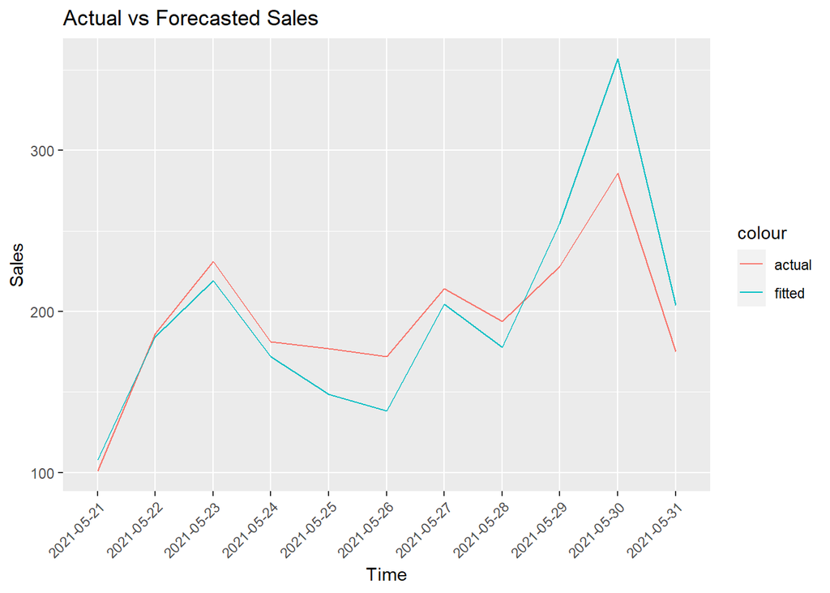

```r
ggplot(bikini1_daily_te ,aes(x=event_date)) +
        geom_line(aes(y=sold_count,color='actual', group=1)) +
        geom_line(aes(y=forecastarimax,color='fitted', group=1)) + labs(title = "Actual vs Forecasted Sales",
       x = "Time",
       y = "Sales"
       )+
  theme(axis.text.x = element_text(angle = 45, hjust=1))
```

Above plot shows the fitted values of the last model. Model fits well with the actual values.

# Trendyol Bikini 2

## Decomposition

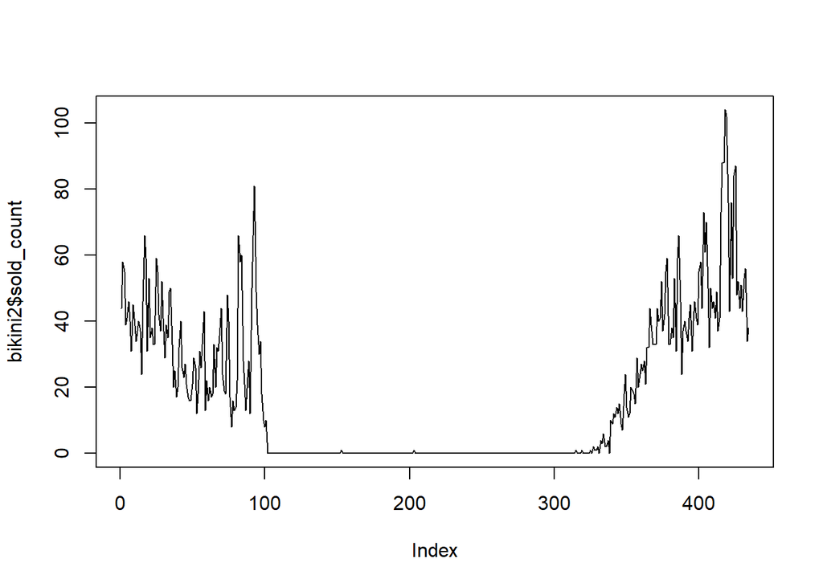

```r
bikini2<-subset(alldata, alldata$product_content_id==32737302)
bikini2_daily_tr<-bikini2[bikini2$event_date<"2021-05-21"]
bikini2_daily_te<-bikini2[bikini2$event_date>="2021-05-21"]
plot(bikini2$sold_count, type='l')
```

Plot above shows the sold counts for bikini2. Sales volumes shows a trend after January.

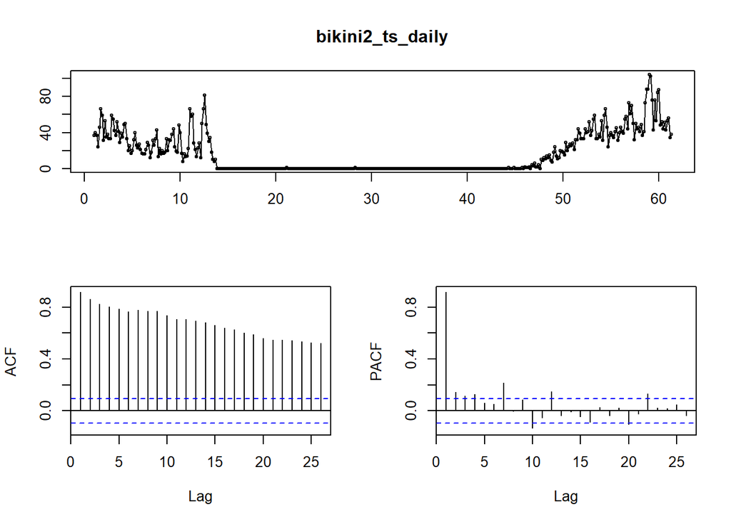

```r
bikini2_ts_daily<-ts(bikini2_daily_tr$sold_count, freq=7)
tsdisplay(bikini2_ts_daily)
```

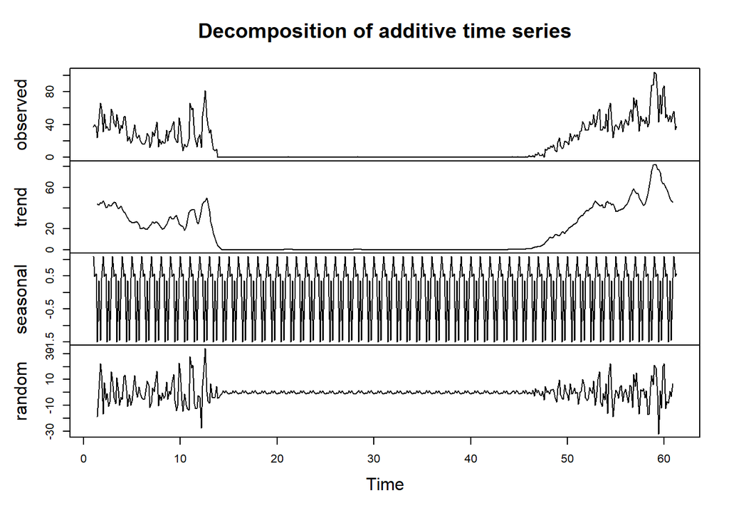

```r
bikini2_daily_additive<-decompose(bikini2_ts_daily, type ="additive")
bikini2_daily_multiplicative<-decompose(bikini2_ts_daily, type ="multiplicative")
plot(bikini2_daily_additive)
```

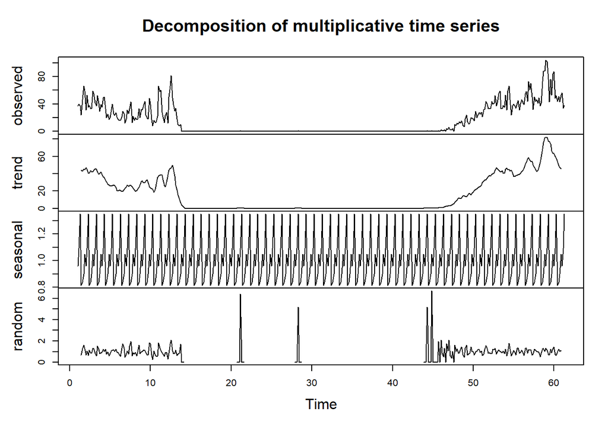

```r
plot(bikini2_daily_multiplicative)
```

```r
test1=ur.kpss(bikini2_daily_additive$random, use.lag="7")
summary(test1)
```

```
##
## #######################
## # KPSS Unit Root Test #
## #######################
##
## Test is of type: mu with 7 lags.
##
## Value of test-statistic is: 0.0123
##
## Critical value for a significance level of:
##                 10pct  5pct 2.5pct  1pct
## critical values 0.347 0.463  0.574 0.739
```

```r
test2=ur.kpss(bikini2_daily_multiplicative$random, use.lag="7")
summary(test2)
```

```
##
## #######################
## # KPSS Unit Root Test #
## #######################
##
## Test is of type: mu with 7 lags.
##
## Value of test-statistic is: 0.0925
##
## Critical value for a significance level of:
##                 10pct  5pct 2.5pct  1pct
## critical values 0.347 0.463  0.574 0.739
```

We can see that the additive model is better by applying the kpss test.

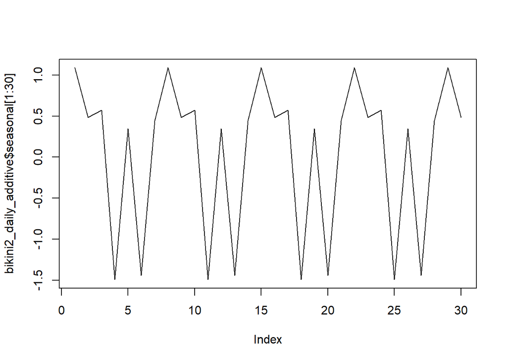

```r
plot(bikini2_daily_additive$seasonal[1:30], type='l')
```

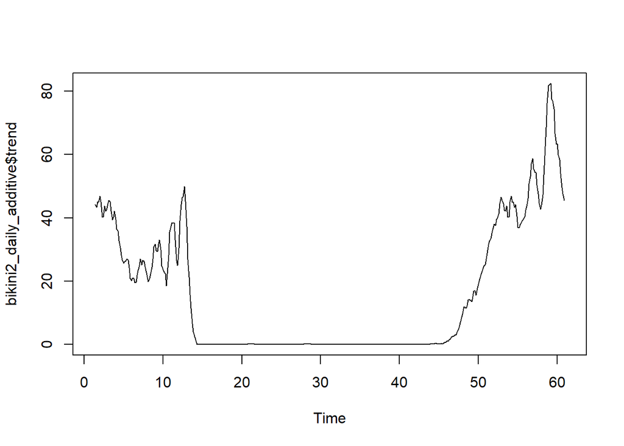

```r
plot(bikini2_daily_additive$trend, type='l')
```

By controlling the seasonal component, we can clearly see the seasonality at the daily level. The charts above show a closer look at the trend and seasonal components of additive divergence.

## ARIMA Model

To decide on the parameters of ARIMA model, autocorrelation and partial autocorrelation of the random component of additive model are investigated.

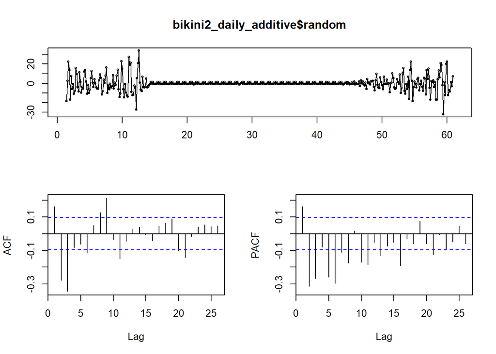

```r
tsdisplay(bikini2_daily_additive$random, na.action = na.omit)
```

```r
bikini2_model<-arima(bikini2_daily_additive$random, order = c(3,0,3))
AIC(bikini2_model)
```

```
## [1] 2585.062
```

```r
bikini2_model2<-arima(bikini2_daily_additive$random, order = c(2,0,3))
AIC(bikini2_model2)
```

```
## [1] 2599.581
```

Model 1 is better in terms of AIC values, therefore it is chosen to construct the ARIMA model.

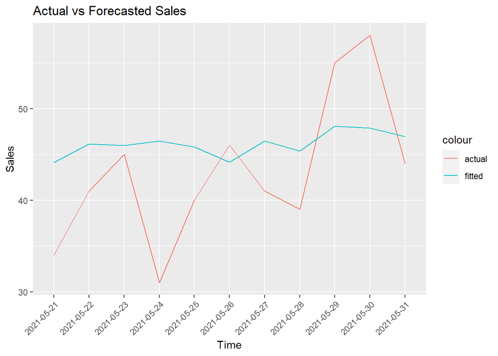

```r
model_forecast_error <- predict(bikini2_model, n.ahead = 11)$pred
last_trend_value <-tail(bikini2_daily_additive$trend[!is.na(bikini2_daily_additive$trend)],1)
seasonality=bikini2_daily_additive$seasonal[295:305]
bikini2_arima_forecast=model_forecast_error+seasonality+last_trend_value
bikini2_daily_te$forecast<-paste(bikini2_arima_forecast)
bikini2_daily_te$forecast<-as.numeric(bikini2_daily_te$forecast)
ggplot(bikini2_daily_te ,aes(x=event_date)) +
        geom_line(aes(y=sold_count,color='actual',group=1)) +
        geom_line(aes(y=forecast,color='fitted',group=1)) + labs(title = "Actual vs Forecasted Sales",
       x = "Time",
       y = "Sales"
       )+
  theme(axis.text.x = element_text(angle = 45, hjust=1))
```

```r
error_test(bikini2_daily_te$sold_count,bikini2_daily_te$forecast)
```

```
##    n     mean      sd        bias      mape      mad    wmape       MPE
## 1 11 43.09091 8.00568 -0.07049063 0.1630037 6.470789 0.150166 -0.101115
```

## Regressor Search

To decide on which regressors to use, 3 different linear models are constructed and compared in terms of their error rates.

```r
bikini2_lm1<-lm(sold_count~price, data=bikini2_daily_tr)
summary(bikini2_lm1)
```

```
##
## Call:
## lm(formula = sold_count ~ price, data = bikini2_daily_tr)
##
## Residuals:
##     Min      1Q  Median      3Q     Max
## -32.736 -15.736  -0.736  10.264  69.891
##
## Coefficients:
##             Estimate Std. Error t value Pr(>|t|)
## (Intercept) -55.8647    55.7562  -1.002    0.318
## price         1.4936     0.9279   1.610    0.109
##
## Residual standard error: 20.41 on 199 degrees of freedom
##   (222 observations deleted due to missingness)
## Multiple R-squared:  0.01285,    Adjusted R-squared:  0.007891
## F-statistic: 2.591 on 1 and 199 DF,  p-value: 0.1091
```

```r
bikini2_lm2<-lm(sold_count~category_sold+price, data=bikini2_daily_tr)
summary(bikini2_lm2)
```

```
##
## Call:
## lm(formula = sold_count ~ category_sold + price, data = bikini2_daily_tr)
##
## Residuals:
##     Min      1Q  Median      3Q     Max
## -38.900  -8.939  -0.500   8.343  45.349
##
## Coefficients:
##                 Estimate Std. Error t value Pr(>|t|)
## (Intercept)   92.3780013 41.4983858   2.226   0.0271 *
## category_sold  0.0082139  0.0005999  13.692   <2e-16 ***
## price         -1.3340549  0.6979724  -1.911   0.0574 .
## ---
## Signif. codes:  0 '***' 0.001 '**' 0.01 '*' 0.05 '.' 0.1 ' ' 1
##
## Residual standard error: 14.67 on 198 degrees of freedom
##   (222 observations deleted due to missingness)
## Multiple R-squared:  0.4929, Adjusted R-squared:  0.4878
## F-statistic: 96.25 on 2 and 198 DF,  p-value: < 2.2e-16
```

```r
bikini2_lm3<-lm(sold_count~favored_count+basket_count, data=bikini2_daily_tr)
summary(bikini2_lm3)
```

```
##
## Call:
## lm(formula = sold_count ~ favored_count + basket_count, data = bikini2_daily_tr)
##
## Residuals:
##     Min      1Q  Median      3Q     Max
## -26.715  -0.160   0.172   0.198  33.938
##
## Coefficients:
##                Estimate Std. Error t value Pr(>|t|)
## (Intercept)   -0.171728   0.372976   -0.46    0.645
## favored_count -0.026582   0.002360  -11.26   <2e-16 ***
## basket_count   0.226502   0.005023   45.09   <2e-16 ***
## ---
## Signif. codes:  0 '***' 0.001 '**' 0.01 '*' 0.05 '.' 0.1 ' ' 1
##
## Residual standard error: 6.078 on 420 degrees of freedom
## Multiple R-squared:  0.9243, Adjusted R-squared:  0.9239
## F-statistic:  2563 on 2 and 420 DF,  p-value: < 2.2e-16
```

```r
bikini2_daily_te$forecastlm1<-predict(bikini2_lm1,bikini2_daily_te)
bikini2_daily_te$forecastlm2<-predict(bikini2_lm2,bikini2_daily_te)
bikini2_daily_te$forecastlm3<-predict(bikini2_lm3,bikini2_daily_te)
error_test(bikini2_daily_te$sold_count,bikini2_daily_te$forecastlm1)
```

```
##    n     mean      sd     bias      mape     mad    wmape       MPE
## 1 11 43.09091 8.00568 0.166204 0.1835171 8.55251 0.198476 0.1402479
```

```r
error_test(bikini2_daily_te$sold_count,bikini2_daily_te$forecastlm2)
```

```
##    n     mean      sd       bias      mape      mad     wmape        MPE
## 1 11 43.09091 8.00568 0.03023812 0.1165133 4.911127 0.1139713 0.03093093
```

```r
error_test(bikini2_daily_te$sold_count,bikini2_daily_te$forecastlm3)
```

```
##    n     mean      sd       bias      mape      mad     wmape        MPE
## 1 11 43.09091 8.00568 0.06301448 0.1136532 4.838151 0.1122778 0.06528443
```

Model 3 wmape is much lower than the wmape of the ARIMA model. Favored count and basket count will be added to the model.

```r
bikini2_xreg1<-cbind(bikini2_daily_tr$favored_count,
                  bikini2_daily_tr$basket_count)
bikini2_xreg2<-cbind(bikini2_daily_te$favored_count,
                  bikini2_daily_te$basket_count)
bikini2_arimax<-Arima(bikini2_ts_daily,xreg=as.matrix(bikini2_xreg1),order=c(2,0,2))
bikini2_daily_te$forecastarimax<-forecast(bikini2_arimax,xreg=as.matrix(bikini2_xreg2))$mean
error_test(bikini2_daily_te$sold_count,bikini2_daily_te$forecastarimax)
```

```
##    n     mean      sd       bias      mape      mad     wmape        MPE
## 1 11 43.09091 8.00568 -0.1032761 0.1298827 5.485887 0.1273096 -0.1093135
```

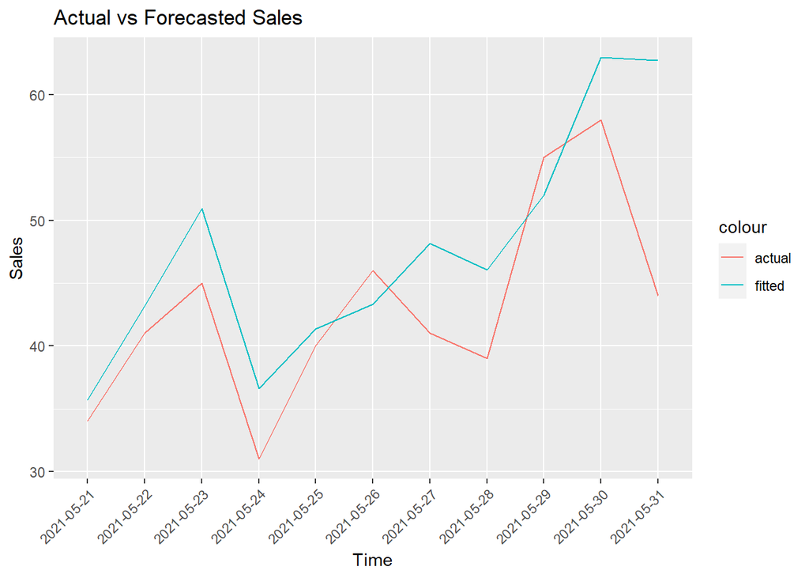

```r
ggplot(bikini2_daily_te ,aes(x=event_date)) +
        geom_line(aes(y=sold_count,color='actual',group=1)) +
        geom_line(aes(y=forecastarimax,color='fitted',group=1)) + labs(title = "Actual vs Forecasted Sales",
       x = "Time",
       y = "Sales"
       )+
  theme(axis.text.x = element_text(angle = 45, hjust=1))
```

Above plot shows the fitted values of the last model. Model fits well with the actual values.

# Oral-B Toothbrush

## Decomposition

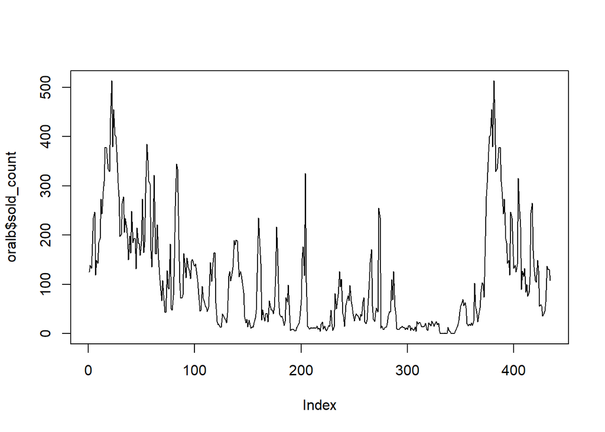

```r
oralb<-subset(alldata, alldata$product_content_id==32939029)
oralb_daily_tr<-oralb[oralb$event_date<"2021-05-21"]
oralb_daily_te<-oralb[oralb$event_date>="2021-05-21"]
plot(oralb$sold_count, type='l')
```

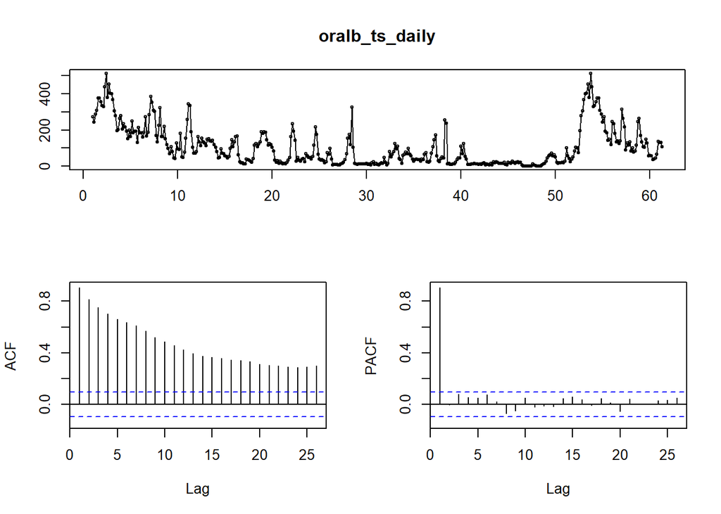

```r
oralb_ts_daily<-ts(oralb_daily_tr$sold_count, freq=7)
tsdisplay(oralb_ts_daily)
```

The ACF plot is highly correlated and the PACF shows significant correlation only at lag 1.

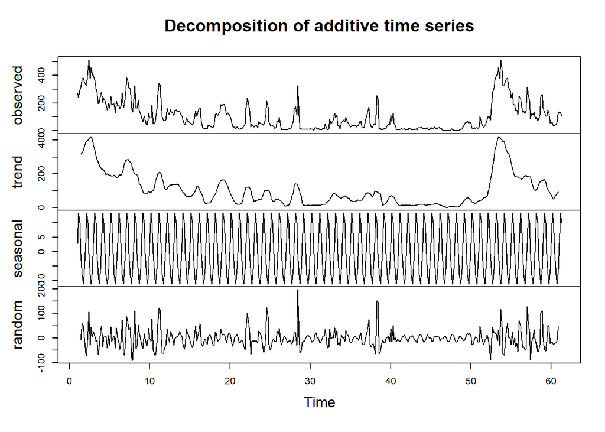

```r
oralb_daily_additive<-decompose(oralb_ts_daily, type ="additive")
oralb_daily_multiplicative<-decompose(oralb_ts_daily, type ="multiplicative")
plot(oralb_daily_additive)
```